# The ggplot2 package

Data analysis and visualization using R 2

Michiel Noback

April 2020

# Keep the goal in mind

You should always remember the purpose with which you create a plot:

1. *Communicate results in a visual way*. The *audience* consists of other professionals. The *scope* is in reports, publications, presentations etc.
2. *Create a representation of data for visual inspection*. The *audience* is yourself. You visualize your data in order to discover patterns, trends, outliers and to generate new questions and hypotheses.

# The R graph gallery

To help your imagination and see what is possible you should really browse through [The R Graph Gallery](https://www.r-graph-gallery.com/). It has code for all the charts in the gallery.

# Getting started

Install the required packages, or the entire `tidyverse` to get them all.

```r
install.packages("ggplot2")
install.packages("tidyr")
```

After installing, you’ll need to load the packages.

```r
library(ggplot2)
library(tidyr)
```

# A first plot

Let’s dive right in and create a first plot.

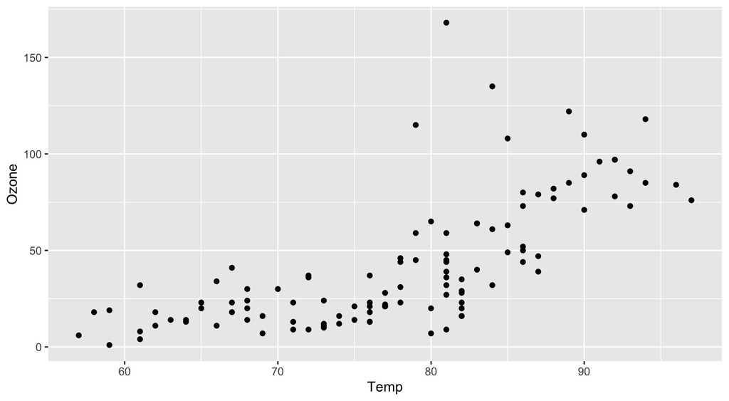

```r
airquality <- na.omit(airquality)
ggplot(data = airquality, mapping = aes(x = Temp, y = Ozone)) +
  geom_point()
```

There are two *chained function calls*: `ggplot()` and `geom_point()`. They are chained using the `+` operator. The first function, `ggplot()`, creates the base layer of the plot It receives the data and defines how it maps to the two axes.

# An empty plot

By itself, `ggplot()`, will not display anything of your data. It creates an empty plot where the axes are defined and have the correct scale:

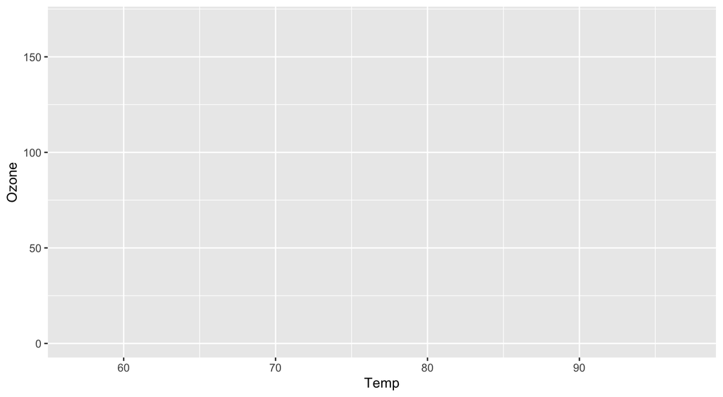

```r
ggplot(data = airquality, mapping = aes(x = Temp, y = Ozone))
```

# Adding a dimension using color

This plot shows the power of ggplot2: building complex visualizations with little code.

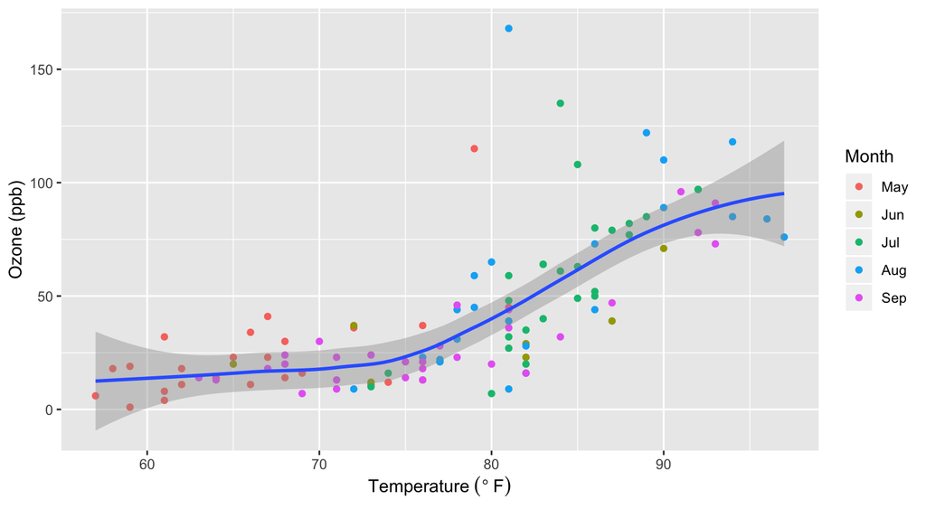

```r
airquality$Month <- factor(airquality$Month, levels=1:12, labels=month.abb)
ggplot(data = airquality, mapping=aes(x=Temp, y=Ozone)) +
  geom_point(mapping=aes(color=Month)) +
  geom_smooth(method="loess") + xlab(expression("Temperature " (degree~F))) +
  ylab("Ozone (ppb)") + labs(color="Month")
```

# ggplot2 and the theory of graphics

# Philosophy of ggplot2

The author of ggplot2, Hadley Wickham, had a very clear goal in mind when he embarked on the development of this package:

*“The emphasis in ggplot2 is reducing the amount of thinking time by making it easier to go from the plot in your brain to the plot on the page.” (Wickham, 2012)*

The way this is achieved is through “*The grammar of graphics*”

# The grammar of graphics

> The grammar of graphics tells us that a statistical graphic is a mapping from data to geometric objects (points, lines, bars) with aesthetic attributes (color, shape, size).

> The plot may also contain statistical transformations of the data and is drawn on a specific coordinate system. Faceting -grid layout- can be used to generate the same plot for different subsets of the dataset.

(Wickham, 2010)

# Building plots with ggplot2

# The layered plot architecture

A graph in ggplot2 is built using a few “layers”, or building blocks.

The three core ggplot2 layers

| ggplot2 | description |
| --- | --- |
| data= | the data that you want to plot |
| aes() | mappings of data to position (axes), colors, sizes |
| geom_…..() | shapes (geometries) that will represent the data |

# The data layer

First, there is the *data* layer - the input data that you want to visualize:

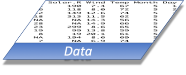

# Aeasthetics

Using the `aes()` function, the data is *mapped* to a coordinate system. This encompasses not only the xy-coordinates but also possible extra plot dimensions such as color and shape.

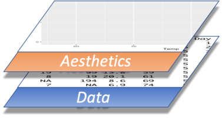

# Geometries

As a third step, the data is *visually represented* in some way, using a *geometry* (dealt with by one of the many `geom_....()` functions). Examples of geometries are *point* for scatterplots, *boxplot*, *line* etc.

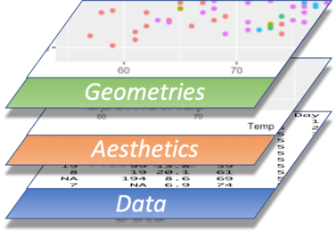

At a minimum, these three layers are used in every plot you create.

# All layers

Besides these fundamental aspects there are other elements you may wish to add or modify: axis labels, legend, titles, etc. These constitute additional, optional layers:

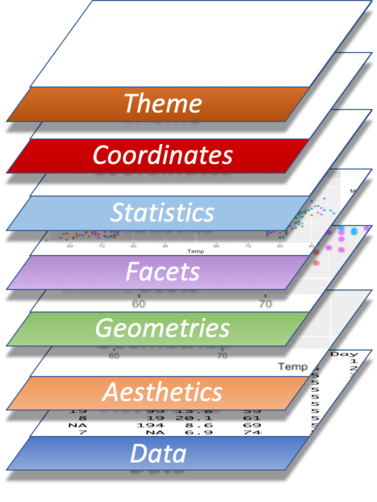

# “Tidy” the data

The ggplot2 function expects its data to come in a *tidy* format.  
A dataset is considered *tidy* when it is formed according to these rules:

1. Each variable has its own column.
2. Each observation has its own row.
3. Each value has its own cell.

# Non-tidy data

Here is an example dataset that requires some mangling, or *tidying*, to adhere to these rules.

| patient | sex | dose10mg | dose100mg |
| --- | --- | --- | --- |
| 001 | f | 12 | 88 |
| 002 | f | 11 | 54 |
| 003 | m | 54 | 14 |
| 004 | m | 71 | 21 |
| 005 | f | 19 | 89 |

Suppose you want to plot the response as a function of the dose. That is not quite possible right now in ggplot2. This is because you want to do something like

```r
ggplot(data=dose_response,
       mapping = aes(x = "<I want to get the dose levels here>",
                     y = "<I want to get the response here>")) +
    geom_boxplot()
```

Luckily, there is a very nice package that makes this quite easy: `tidyr`.

# Tidying data using `tidyr::pivot_longer()`

```r
library(tidyr)
dose_response_tidy <- pivot_longer(data = dose_response,
                              cols = 3:4,
                              names_to = "dose",
                              values_to = "response",
                              names_prefix = "dose")
head(dose_response_tidy)
```

```
## # A tibble: 6 x 4
##   patient sex   dose  response
##   <chr>   <fct> <chr>    <int>
## 1 001     f     10mg        12
## 2 001     f     100mg       88
## 3 002     f     10mg        11
## 4 002     f     100mg       54
## 5 003     m     10mg        54
## 6 003     m     100mg       14
```

# Convert dose to factor

Transform dose column to nice factor

```r
dose_response_tidy$dose <- factor(ifelse(
    dose_response_tidy$dose == "10mg", 10, 100),
  ordered = T)
knitr::kable(head(dose_response_tidy, n=10))
```

| patient | sex | dose | response |
| --- | --- | --- | --- |
| 001 | f | 10 | 12 |
| 001 | f | 100 | 88 |
| 002 | f | 10 | 11 |
| 002 | f | 100 | 54 |
| 003 | m | 10 | 54 |
| 003 | m | 100 | 14 |
| 004 | m | 10 | 71 |
| 004 | m | 100 | 21 |
| 005 | f | 10 | 19 |
| 005 | f | 100 | 89 |

The data is tidy now, and ready for use within ggplot2.

Now, creating the plot in ggplot2 is a breeze

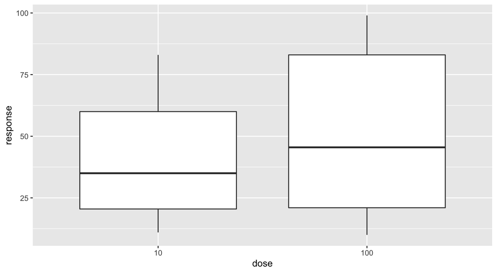

```r
ggplot(dose_response_tidy, aes(x = dose, y = response)) + geom_boxplot()
```

Would you proceed with this hypothetical drug?

# Aesthetics

Aesthetics defines the way the data are represented in your plot. You could correlate the aesthetics to the *dimensions* of the data you want to visualize. For instance with the airquality dataset the aesthetics were defined in three “dimensions”:

- dimension “X” for temperature,
- dimension “Y” for Ozone
- dimension “color” for the month.

Although color is used most often to represent an extra dimension in the data, other aesthetics you may consider are shape, size, line width and line type.

# Colors

- Colors can be defined in a variety of ways:
  - color name
  - existing color palette
  - custom color palette
- When you provide a literal (character) for the color it will simply be that color.
- If you want to map a property (e.g. “Month”) to a range of colors it should be specified within the `aes()` call.
- Since ggplot has build-in color palettes, you can simply use `color=<my-third-dimension-variable>`.

# The default palette

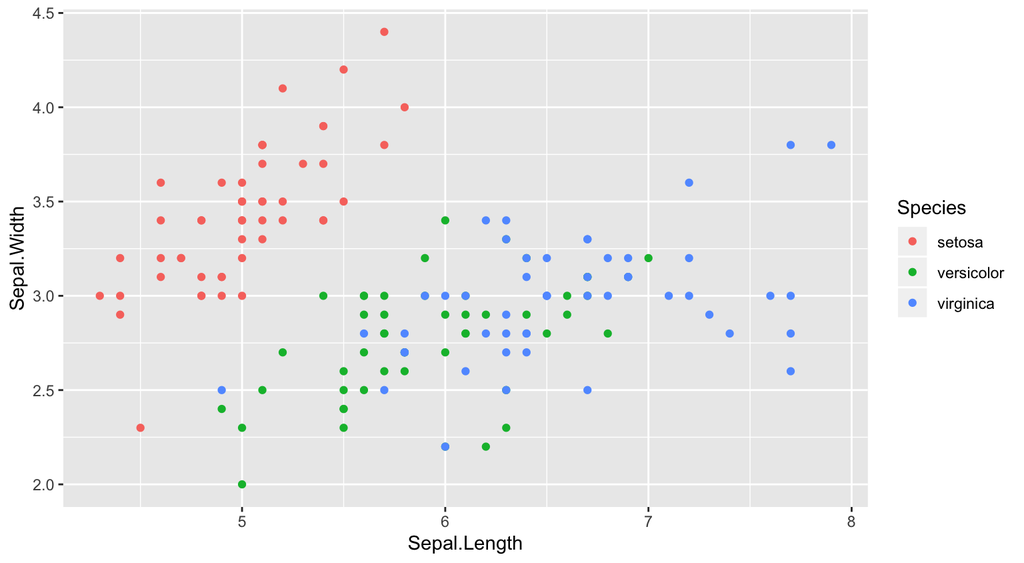

```r
sp <- ggplot(iris, aes(Sepal.Length, Sepal.Width)) +
  geom_point(aes(color = Species))
sp
```

# Manual palettes

You can specify your own colors using `scale_color_manual()` for scatter plots or `scale_fill_manual()` for boxplots and bar plots.

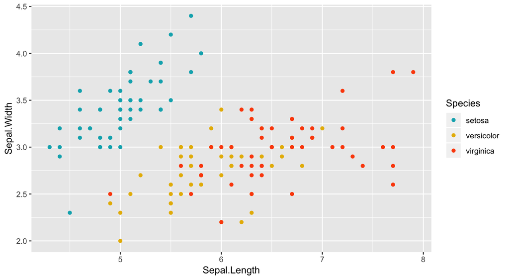

```r
sp + scale_color_manual(values = c("#00AFBB", "#E7B800", "#FC4E07"))
```

# RColorBrewer palettes

- The “RColorBrewer” package provides several palettes through the `brewer.pal()` function.
- Have a look at `brewer.pal.info` for all pallettes.

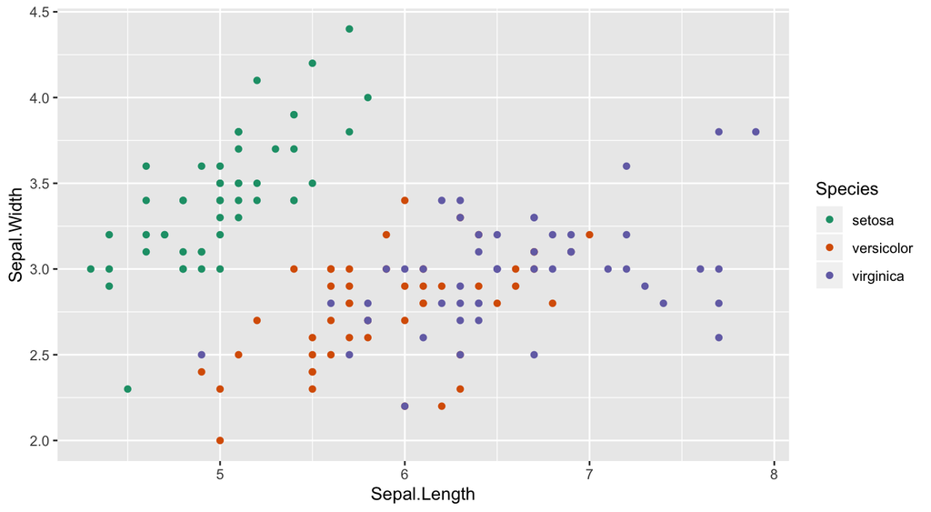

```r
library(RColorBrewer)
ggplot(iris, aes(Sepal.Length, Sepal.Width)) +
  geom_point(aes(color = Species)) +
  scale_colour_manual(values=brewer.pal(6, "Dark2")) #only 3 required
```

# Shapes

These are the shapes available in ggplot2 (and base R as well).

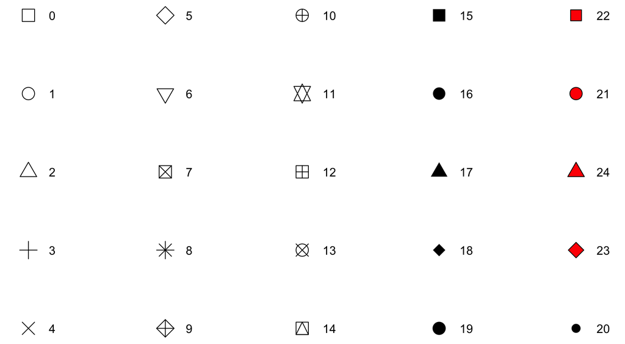

Warning: do not clutter your plot with too many dimensions/aesthetics!

# Lines

- Geoms that draw lines have a “linetype” parameter.
- Legal values are the strings “blank”, “solid”, “dashed”, “dotted”, “dotdash”, “longdash”, and “twodash”.
- Alternatively, the numbers 0 to 6 can be used (0 for “blank”, 1 for “solid”, …).
- As with colors, you can set line type to a constant value or use it dynamically.

Here is an example where the female and male deaths in the UK for 72 successive months are plotted.

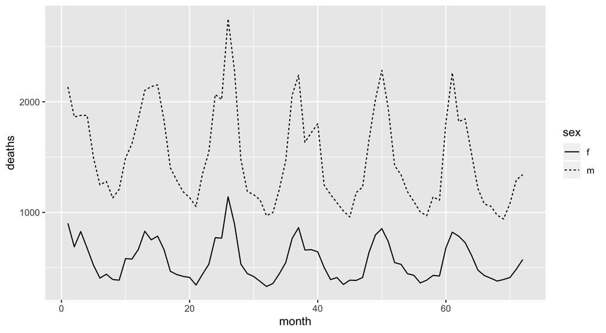

```r
ggplot(data = deaths, mapping = aes(x = month, y = deaths, linetype=sex)) +
    geom_line()
```

# Size

The size of the plotting symbol can also be used as an extra “dimension” in your visualization.  
Here is an example showing the solar radiation of the airquality data as third dimension.

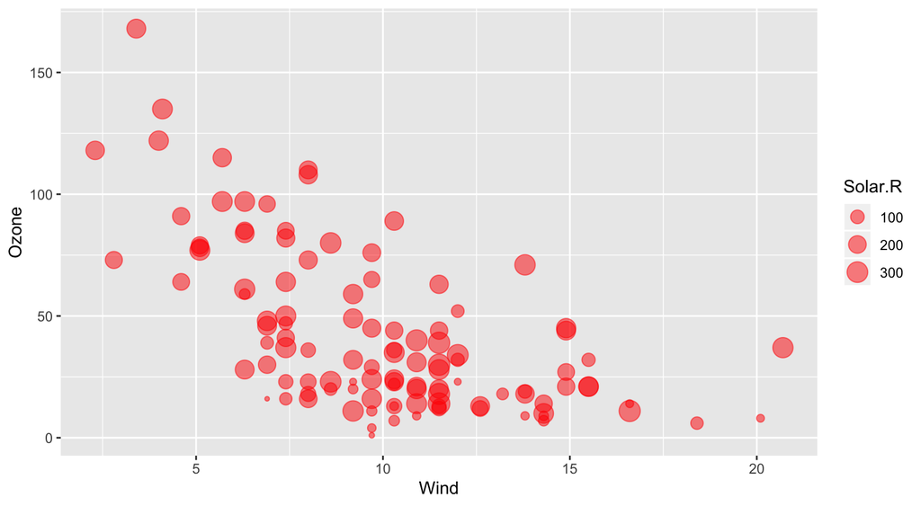

```r
ggplot(data = na.omit(airquality),
       mapping = aes(x = Wind, y = Ozone, size=Solar.R)) +
    geom_point(color="red", alpha=0.5)
```

# Geometries

# What are geometries

- Geometries are the ways data can be visually represented. Boxplot, scatterplot and histogram are a few examples.
- There are *many* geoms available in ggplot2; type `geom_` in the console and you will get a listing.
- Even more are available outside the ggplot2 package. Here we’ll only explore a few.

# Boxplot

Boxplot displays the 5-number summary containing from bottom to top: minimum, first quartile, median (= second quartile), third quartile, maximum. Outliers, usually defined as more than `1.5 * IQR` from the median, are displayed as separate points.

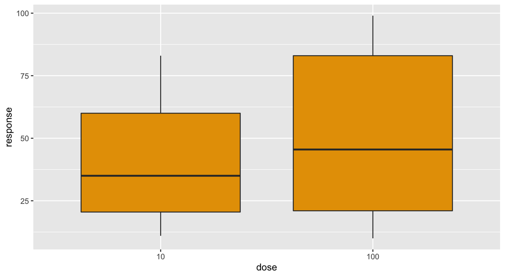

```r
dr_plot <- ggplot(dose_response_tidy, aes(x = dose, y = response))
dr_plot + geom_boxplot(fill='#E69F00')
```

# Jitter

Jitter is a good alternative to boxplot when you have small sample sizes, or discrete measurements with many exact copies, resulting in much overlap.  
Use the width and height attributes to adjust the jittering.

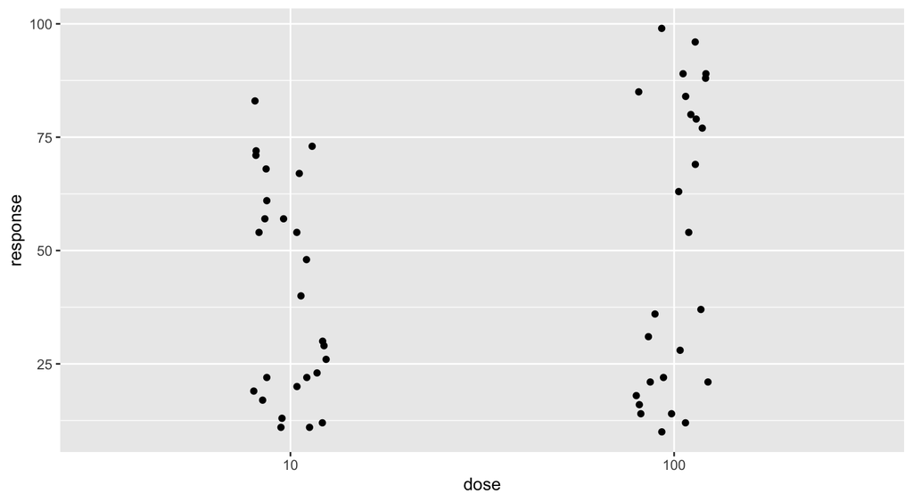

```r
dr_plot + geom_jitter(width = 0.1, height = 0)
```

Here, a split over the sexes is added. Suddenly, a dramatic dosage effect becomes apparent that was smoothed out when the two sexes were combined.

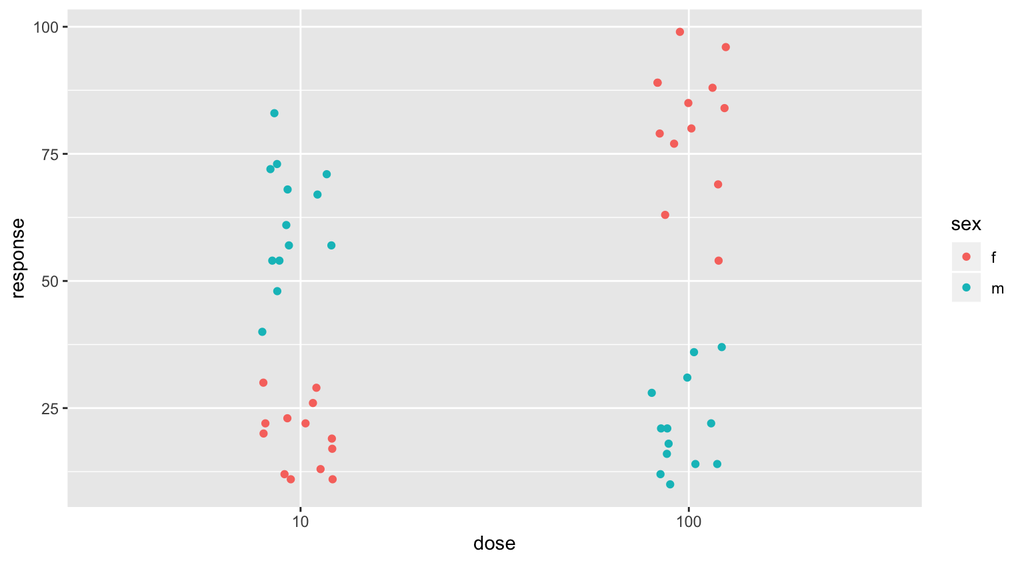

```r
dr_plot + geom_jitter(width = 0.1, height = 0, aes(colour = sex))
```

Alternatively, use a grid of plots

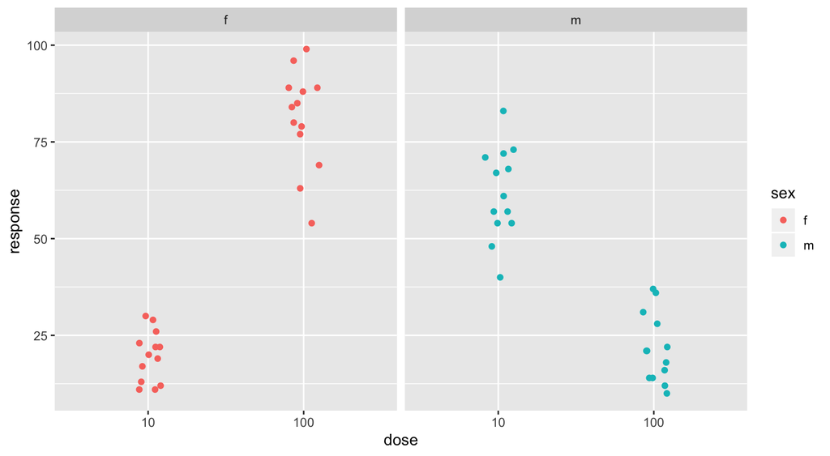

```r
dr_plot +
    geom_jitter(width = 0.1, height = 0, aes(colour = sex)) +
    facet_wrap( . ~ sex)
```

# Plot overlays: boxplot + jitter

This example shows how you can overlay plots on top of each other as much as you like.

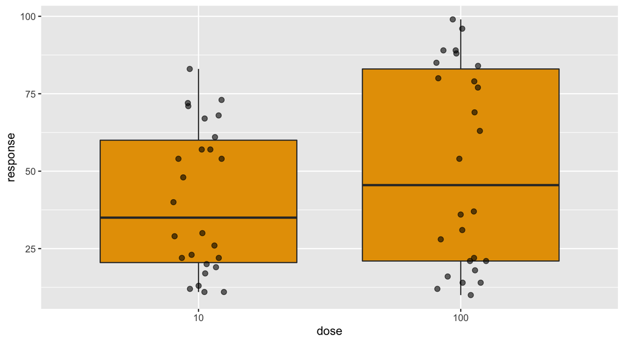

```r
dr_plot <- ggplot(dose_response_tidy, aes(x = dose, y = response))
dr_plot +
    geom_boxplot(fill='#E69F00') +
    geom_jitter(width = 0.1, height = 0, size = 2, alpha = 0.6)
```

# Scatterplot: Points

The `geom_point()` function is used to create the good old scatterplot of which we have seen quite a few examples already.

When points can be logically connected it may be a good idea to use a line to visualize trends, as we have seen in the `deaths` plot in section Aesthetics

# Histograms

A histogram is a means to visualize a distribution.  
Here we look at the eruption intervals of the “faithful” geyser.  
Use `binwidth` or `bins` argument to adjust the number of bins.

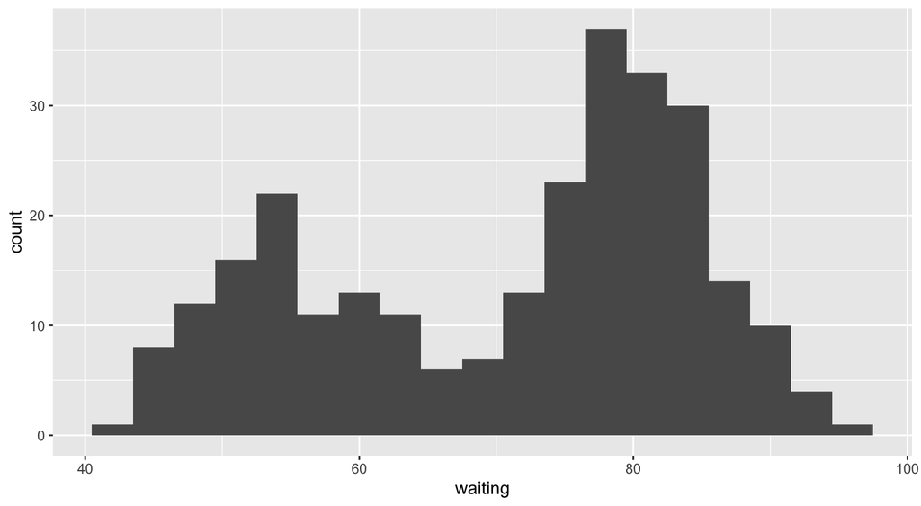

```r
ggplot(data=faithful, mapping = aes(x = waiting)) +
    geom_histogram(binwidth = 3)
```

- You can adjust what is shown on the y axis. The default is `stat(count)`.
- To scale to a maximum of 1 use `stat(count / max(count))`.
- The `stat()` function is a flag to ggplot2 that you want to use a calculated aesthetics.

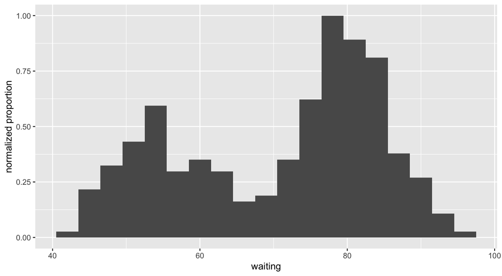

```r
ggplot(data=faithful, mapping = aes(x = waiting)) +
    geom_histogram(binwidth = 3, aes(y = stat(count / max(count)))) +
    ylab(label = "normalized proportion")
```

If you want percentages, you can use `y = stat(count / sum(count) * 100)`.

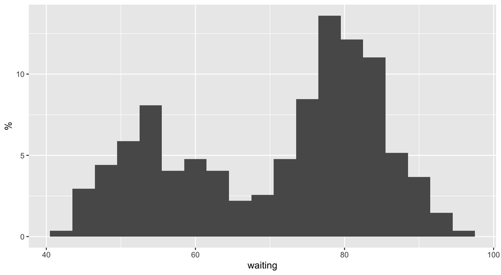

```r
ggplot(data=faithful, mapping = aes(x = waiting)) +
    geom_histogram(binwidth = 3, mapping = aes(y = stat(count / sum(count) * 100))) +
    ylab(label = "%")
```

# Violin plot

-A violin plot is a blend of geom_boxplot() and geom_density(): a violin plot is a mirrored density plot displayed in the same way as a boxplot.

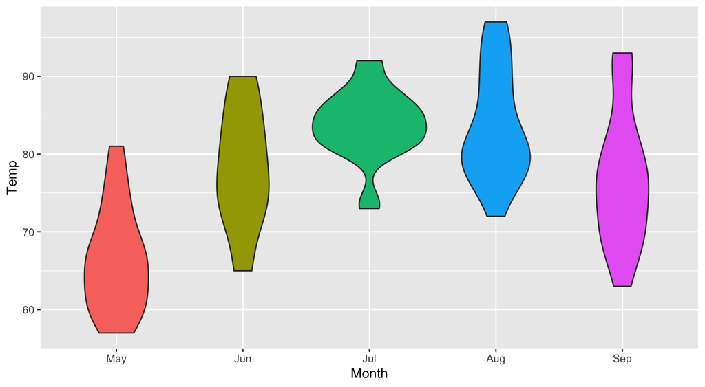

```r
ggplot(data=airquality, mapping = aes(x = Month, y = Temp, fill=Month)) +
    geom_violin() + theme(legend.position = "none")
```

# Barplot

Here is a small example where the ten subjects of the `sleep` dataset have been charted.  
When no weight is provided, the occurrences of the different group levels will be counted and used as weight.

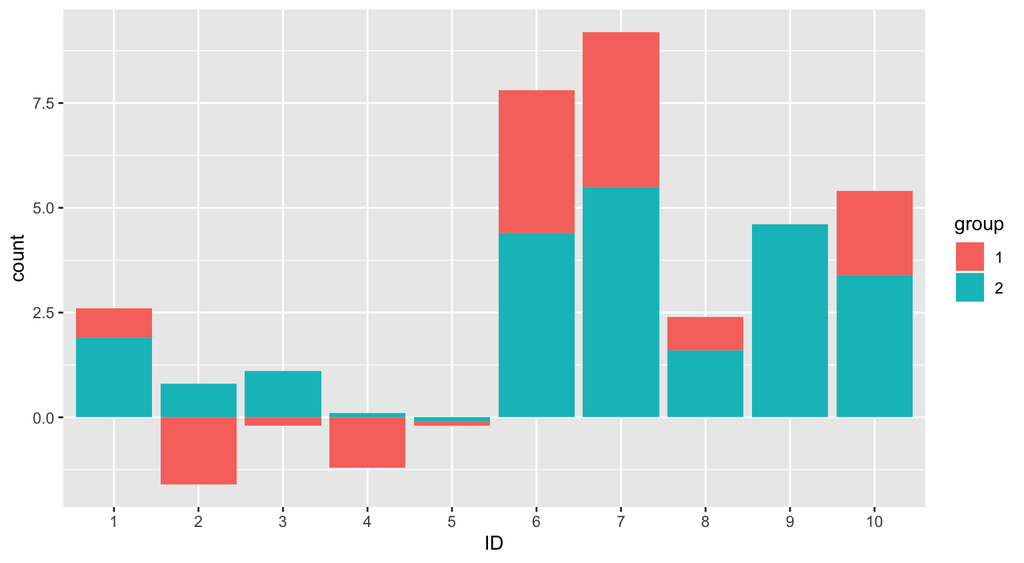

```r
ggplot(data = sleep,
       mapping = aes(ID)) +
    geom_bar(aes(weight = extra, fill = group))
```

# Overview of the main geoms

Here is a small overview of some of the other available geoms. If you want to know them all, simply type `?geom_` and select the one that looks like the thing you want.

Some more geoms

|  | function. | description |
| --- | --- | --- |
| 1 | geom_abline() | Add reference lines to a plot, either horizontal, vertical, or diagonal |
| 3 | geom_density() | Computes and draws kernel density estimate, which is a smoothed version of the histogram |
| 5 | geom_path() | Connects the observations in the order in which they appear in the data |
| 6 | geom_qq() | geom_qq and stat_qq produce quantile-quantile plots |

# Inheritance of aesthetics

- Like the main `ggplot()` function, every `geom_` function accepts its own `mapping = aes(...)`.
- The mapping is *inherited* from the ggplot() function.
- Aesthetics defined locally within a `geom_` function are scoped to that function only.
- The plot below demonstrates the use of multiple `aes()` mappings.
- Any aesthetic value specified outside the aes() function is simply a static property.

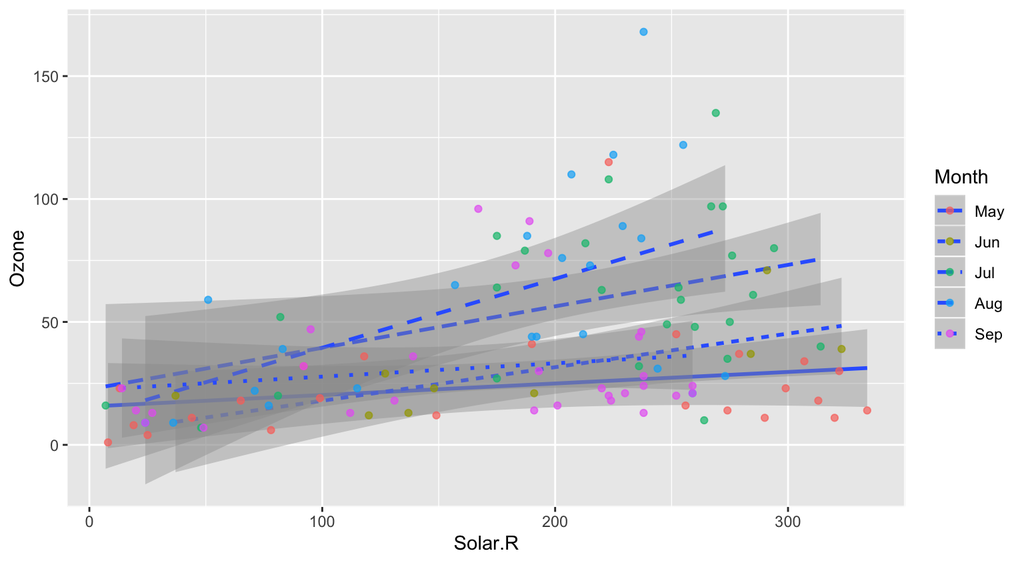

```r
ggplot(data = airquality, mapping = aes(x = Solar.R, y = Ozone)) +
    geom_smooth(aes(linetype = Month), method="lm") +
    geom_point(aes(color = Month), alpha = 0.7)
```

# Faceting

Faceting is the process of splitting into multiple plots with exactly the same coordinate system where each plot show a subset of the data.

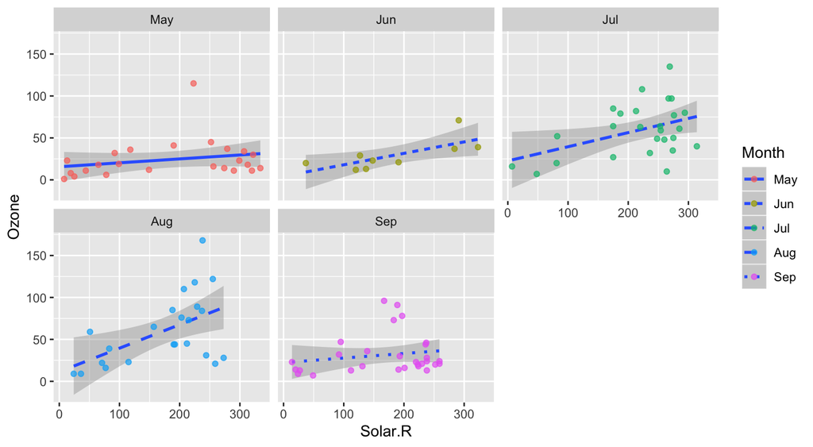

```r
ggplot(data = airquality, mapping = aes(x = Solar.R, y = Ozone)) +
    geom_smooth(aes(linetype = Month), method="lm") +
    geom_point(aes(color = Month), alpha = 0.7) + facet_wrap(. ~ Month)
```

# Experimenting with geoms and aesthetics

The process in plotting using ggplot2 is usually very iterative.  
You start with the base plot, passing it the *aesthetic* for x and y, as shown above, and then experiment with *geometries*, *colors* and *faceting*.

Look at every result and ask yourself

- what story does is tell?
- is it the story you seek to tell?

# Final tweaks

# Scales, Coordinates and Annotations

- Scales and Coordinates are used to adjust the way your data is mapped and displayed.
- This plot shows two usages.

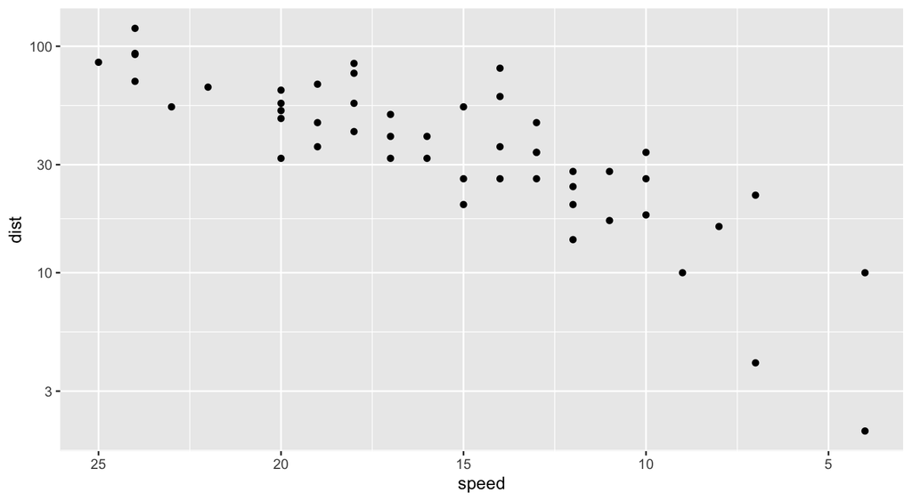

```r
ggplot(data = cars, mapping = aes(x = speed, y = dist)) +
    geom_point() +
    scale_y_log10() +
    scale_x_reverse()
```

# Themes

- The theme is used to make changes to the overall appearance of the plot.
- Two approaches exist.
  - The simplest one is selecting a specific theme and make some minor adjustments at most.
  - In the other approach you specify *everything* yourself.

Here is the minimal theme where the text sizes have been modified somewhat.

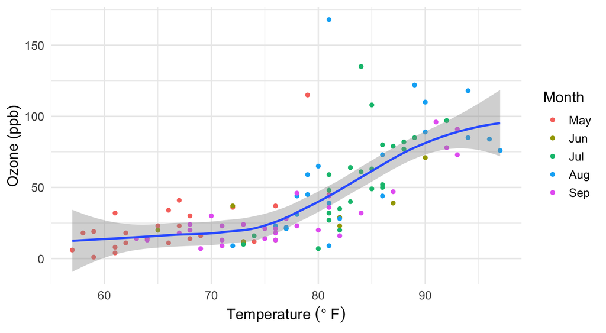

```r
ggplot(data = airquality, mapping=aes(x=Temp, y=Ozone)) +
  geom_point(mapping = aes(color = Month)) +
  geom_smooth(method = "loess") +
  xlab(expression("Temperature " (degree~F))) +
  ylab("Ozone (ppb)") +
  labs(color="Month") +
  theme_minimal(base_size = 14)
```

If the `color = Month` aesthetic would have been put in the main ggplot call, the smoother would have been split over the Month groups.

Alternatively, the theme can be specified completely, as show below.

```r
ggplot(data = airquality, mapping=aes(x=Temp, y=Ozone)) +
  geom_point(mapping=aes(color=Month)) + geom_smooth(method="loess") +
  xlab("Temperature (F)") + ylab("Ozone (ppb)") + labs(color="Month") +
  theme(axis.text.x = element_text(size = 12, colour = "blue", face = "bold"),
        axis.text.y = element_text(size = 12, colour = "red", face = "bold"),
        axis.title.x = element_text(size = 16, colour = "blue", face = "bold.italic"),
        axis.title.y = element_text(size = 14, colour = "red", face = "bold.italic"),
        axis.line = element_line(colour = "darkblue", size = 1, linetype = "solid"),
        panel.background = element_rect(fill = "lightblue", size = 0.5, linetype = "solid"),
        panel.grid.minor = element_blank())
```

As you can see, there are `element_text()`, `element_line()` and `element_rect()` functions to specify these types of plot elements. The `element_blank()` function can be used in various theme aspects to prevent it from being displayed.  
Plot on next slide.

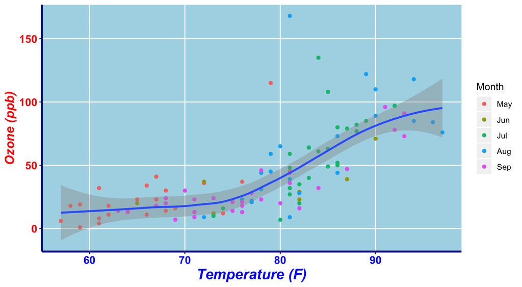

# Annotation

- A final layer that can be added is one containing *annotations*.
- Annotations are elements that are added manually to the plot: a text label, a fictitious data point, a shaded box or an arrow indicating a region of interest.
- In the `annotate()` method, you specify the geom you wish to add (e.g. “text”, “point”). The panel below demonstrates a few.

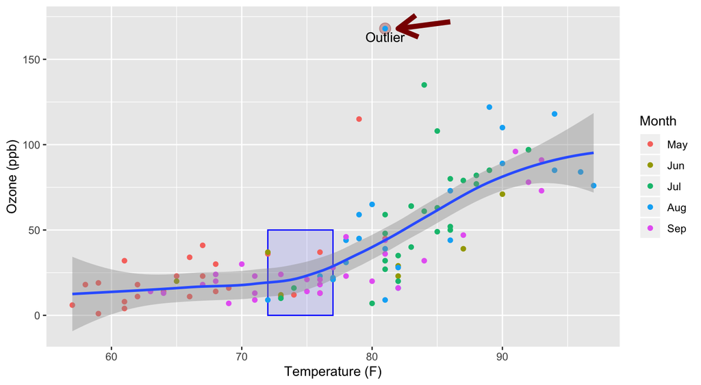

```r
outlier <- airquality[!is.na(airquality$Ozone) & airquality$Ozone > 150, ]

ggplot(data = na.omit(airquality), mapping=aes(x=Temp, y=Ozone)) +
  annotate("rect", xmin=72, xmax=77, ymin=0, ymax=50,
           alpha=0.1, color="blue", fill="blue") +
  annotate("point", x = outlier$Temp, y = outlier$Ozone,
           color = "darkred", size = 4, alpha = 0.3) +
  geom_point(mapping=aes(color=Month)) + geom_smooth(method="loess") +
  xlab("Temperature (F)") + ylab("Ozone (ppb)") +
  annotate("text", x = outlier$Temp, y = outlier$Ozone -5, label = "Outlier") +
  annotate("segment", x = outlier$Temp + 5, xend = outlier$Temp + 1,
           y = outlier$Ozone + 4, yend = outlier$Ozone,
           color = "darkred", size = 2, arrow = arrow())
```